# Exploratory_Analysis_Slide_Deck slides

## Communicating Data Findings: Prosper Loan Data

Prepared by: Piyush Kumar

**What is the structure of this dataset?**

This data set contains 113,937 loans with 81 variables on each loan, including loan amount, borrower rate (or interest rate), current loan status, borrower income, employment status, homeownership, Prosper Ratings, Credit Score, Credit Rating, Payment Information and many others. We have too many for the purpose of visualization, I have cut down a few variables.

**What is/are the main feature(s) of interest in your dataset?**

What factors are responsible for Loan Grant. We would also be looking for any specific relationship between these variables.

**What features in the dataset do you think will help support your investigation into your feature(s) of interest?**

Borrower information occupation, income, Home ownership , Employment Status, prosper rating and Loan Status will be major contributing factors.

### Univariate Analysis:

#### Categorical Variables:

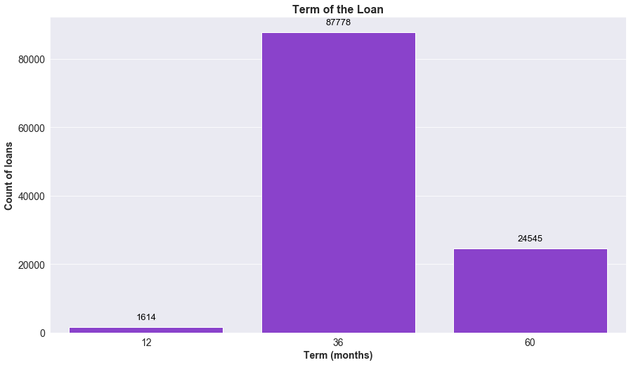

```python
plt.figure(figsize=[14.70, 8.27])
sns.set_palette("bright")
ax=sns.barplot(cat_loan.Term.value_counts().index, cat_loan.Term.value_counts(), color=sns.color_palette()[4])
plt.title('Term of the Loan', fontsize=16,fontweight='bold')
plt.ylabel('Count of loans', fontsize=14,fontweight='bold')
plt.xlabel('Term (months)',  fontsize=14,fontweight='bold')
plt.xticks(fontsize=14)
plt.yticks(fontsize=14);
for p in ax.patches:
             ax.annotate("%.0f" % p.get_height(), (p.get_x() + p.get_width() / 2., p.get_height()),
                 ha='center', va='top', fontsize=13, color='black', xytext=(0, 20),
                 textcoords='offset points')
```

- Most of the loans has term of 36 months.

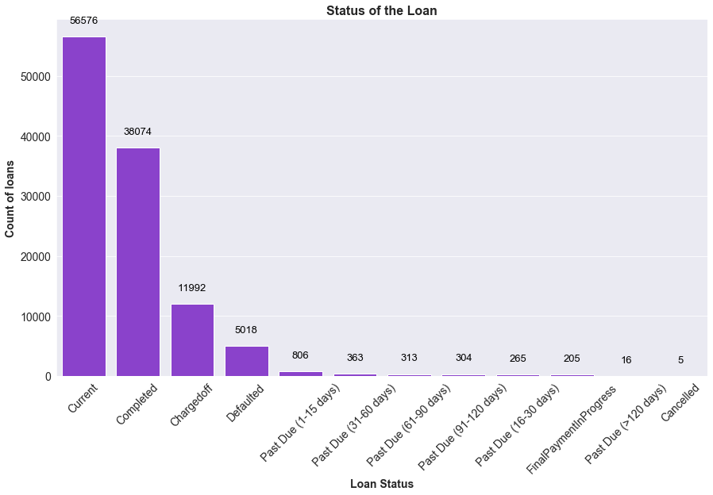

```python
plt.figure(figsize=[14.70, 8.27])
sns.set_palette("bright")
ax=sns.barplot(cat_loan.LoanStatus.value_counts().index, cat_loan.LoanStatus.value_counts(), color=sns.color_palette()[4])
plt.title('Status of the Loan', fontsize=16,fontweight='bold')
plt.ylabel('Count of loans', fontsize=14,fontweight='bold')
plt.xlabel('Loan Status',  fontsize=14,fontweight='bold')
plt.xticks(fontsize=14, rotation=45)
plt.yticks(fontsize=14);
for p in ax.patches:
             ax.annotate("%.0f" % p.get_height(), (p.get_x() + p.get_width() / 2., p.get_height()),
                 ha='center', va='center', fontsize=13, color='black', xytext=(0, 20),
                 textcoords='offset points')
```

- Although, a good no. of loans have been completed, most are still are current.

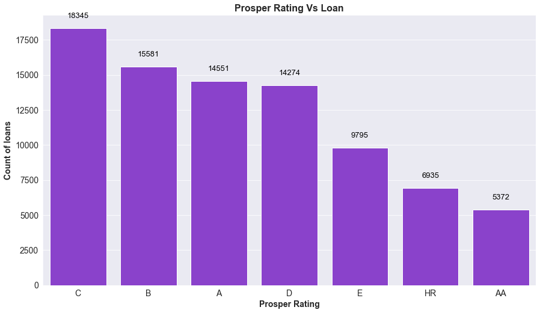

```python
plt.figure(figsize=[14.70, 8.27])
sns.set_palette("bright")
ax=sns.barplot(cat_loan.ProsperRatingAlpha.value_counts(sort=True, dropna=False).index, cat_loan.ProsperRatingAlpha.value_counts(sort=True,dropna=False), color=sns.color_palette()[4])
plt.title('Prosper Rating Vs Loan', fontsize=16,fontweight='bold')
plt.ylabel('Count of loans', fontsize=14,fontweight='bold')
plt.xlabel('Prosper Rating',  fontsize=14,fontweight='bold')
plt.xticks(fontsize=14)
plt.yticks(fontsize=14);
for p in ax.patches:
             ax.annotate("%.0f" % p.get_height(), (p.get_x() + p.get_width() / 2., p.get_height()),
                 ha='center', va='center', fontsize=13, color='black', xytext=(0, 20),
                 textcoords='offset points')
```

- Among the rated loans, C, B, A and D ratings are most prevalent.

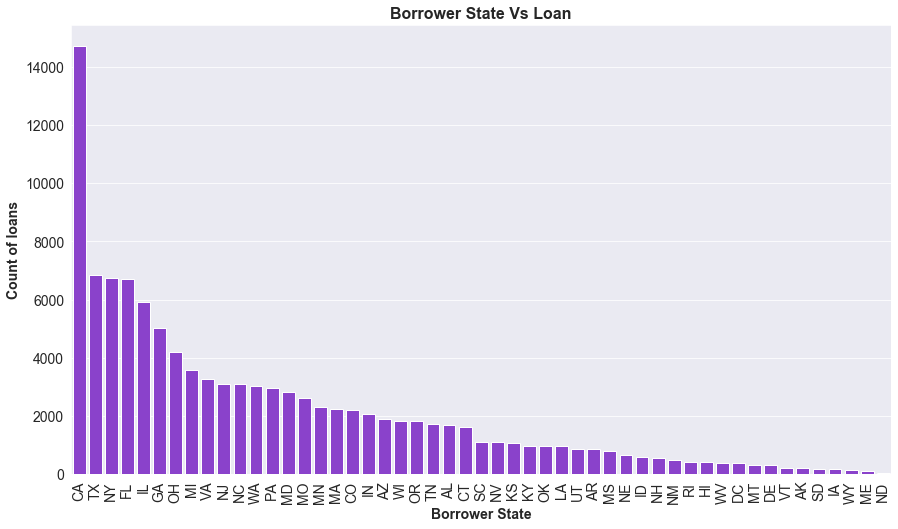

```python
plt.figure(figsize=[14.70, 8.27])
sns.set_palette("bright")
ax=sns.barplot(cat_loan.BorrowerState.value_counts(sort=True, dropna=False).index, cat_loan.BorrowerState.value_counts(sort=True,dropna=False), color=sns.color_palette()[4])
plt.title('Borrower State Vs Loan', fontsize=16,fontweight='bold')
plt.ylabel('Count of loans', fontsize=14,fontweight='bold')
plt.xlabel('Borrower State',  fontsize=14,fontweight='bold')
plt.xticks(fontsize=14, rotation= 90)
plt.yticks(fontsize=14);
```

- Notably, most of the borrowers live in CA, followed by TX, NY, FL and IL.

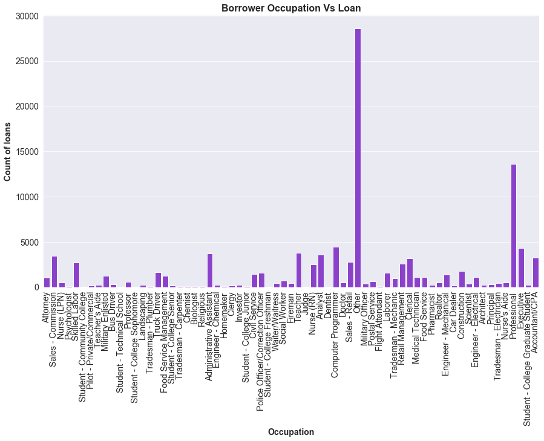

```python
plt.figure(figsize=[14.70, 8.27])
sns.set_palette("bright")
ax=sns.barplot(cat_loan.Occupation.value_counts(sort=False, dropna=False).index, cat_loan.Occupation.value_counts(sort=False,dropna=False), color=sns.color_palette()[4])
plt.title('Borrower Occupation Vs Loan', fontsize=16,fontweight='bold')
plt.ylabel('Count of loans', fontsize=14,fontweight='bold')
plt.xlabel('Occupation',  fontsize=14,fontweight='bold')
plt.xticks(fontsize=14,rotation=90)
plt.yticks(fontsize=14);
```

- Most of the borrowers fall under Others category though a many of them have said they're professional.

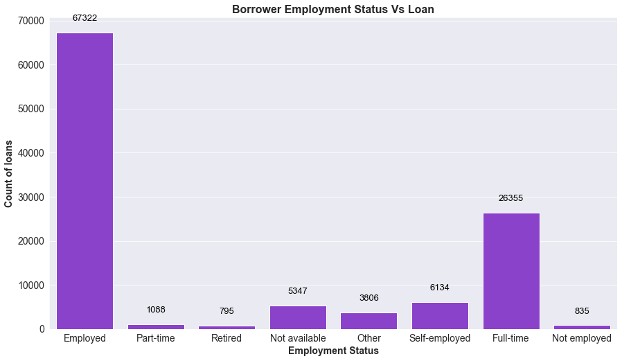

```python
plt.figure(figsize=[14.70, 8.27])
sns.set_palette("bright")
ax=sns.barplot(cat_loan.EmploymentStatus.value_counts(sort=False, dropna=False).index, cat_loan.EmploymentStatus.value_counts(sort=False,dropna=False), color=sns.color_palette()[4])
plt.title('Borrower Employment Status Vs Loan', fontsize=16,fontweight='bold')
plt.ylabel('Count of loans', fontsize=14,fontweight='bold')
plt.xlabel('Employment Status',  fontsize=14,fontweight='bold')
plt.xticks(fontsize=14)
plt.yticks(fontsize=14);
for p in ax.patches:
             ax.annotate("%.0f" % p.get_height(), (p.get_x() + p.get_width() / 2., p.get_height()),
                 ha='center', va='center', fontsize=13, color='black', xytext=(0, 20),
                 textcoords='offset points')
```

- Most of the borrowers are employed and only a few hundreds are unemployed, which is a healthy sign.

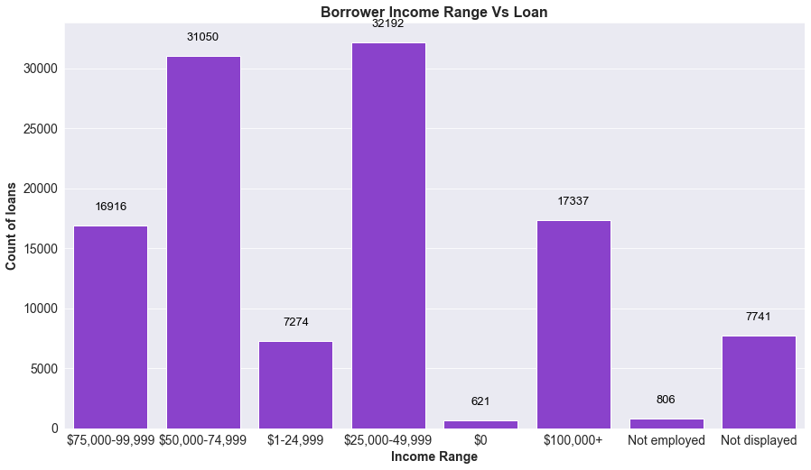

```python
plt.figure(figsize=[14.70, 8.27])

sns.set_palette("bright")
ax=sns.barplot(cat_loan.IncomeRange.value_counts(sort=False, dropna=False).index, cat_loan.IncomeRange.value_counts(sort=False,dropna=False), color=sns.color_palette()[4])
plt.title('Borrower Income Range Vs Loan', fontsize=16,fontweight='bold')
plt.ylabel('Count of loans', fontsize=14,fontweight='bold')
plt.xlabel('Income Range',  fontsize=14,fontweight='bold')
plt.xticks(fontsize=14)
plt.yticks(fontsize=14);
for p in ax.patches:
             ax.annotate("%.0f" % p.get_height(), (p.get_x() + p.get_width() / 2., p.get_height()),
                 ha='center', va='center', fontsize=13, color='black', xytext=(0, 20),
                 textcoords='offset points')
```

- Borrowers Income range follows a normal distribution, where most of the borrowers have Income in the range \$25000 - \\$75000

#### Numerical Variables:

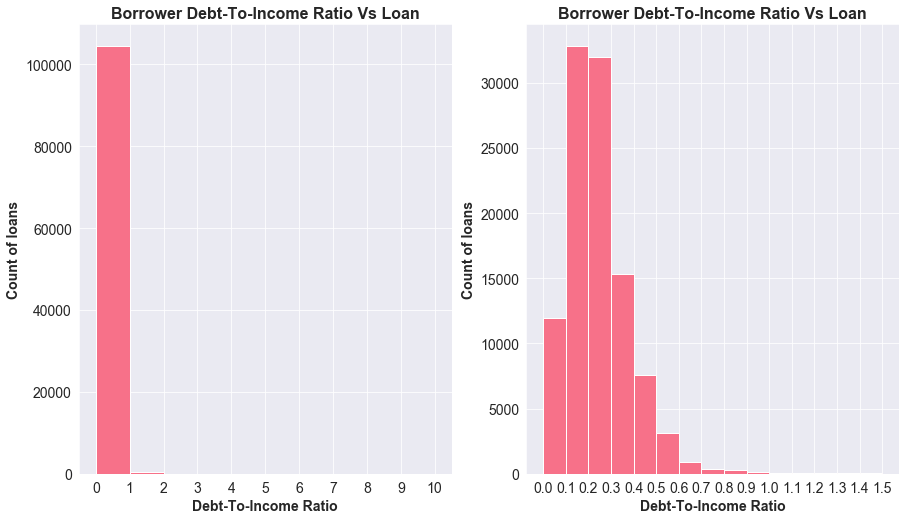

```python
plt.figure(figsize=[14.70, 8.27])
sns.set_palette("husl")


plt.subplot(1,2,1)
bin_edges = np.arange(0, num_loan['DebtToIncomeRatio'].max()+0.1, 1)
plt.hist(data=num_loan, x='DebtToIncomeRatio', bins=bin_edges);
plt.xticks(np.arange(0, num_loan['DebtToIncomeRatio'].max()+0.1, 1),fontsize=14);
plt.yticks(fontsize=14);
plt.title('Borrower Debt-To-Income Ratio Vs Loan', fontsize=16,fontweight='bold')
plt.ylabel('Count of loans', fontsize=14,fontweight='bold')
plt.xlabel('Debt-To-Income Ratio',  fontsize=14,fontweight='bold')

plt.subplot(1,2,2)
bin_edges = np.arange(0, 1.6, 0.1)
plt.hist(data=num_loan, x='DebtToIncomeRatio', bins=bin_edges);
plt.xticks(np.arange(0, 1.6, 0.1),fontsize=14)
plt.yticks(fontsize=14);
plt.title('Borrower Debt-To-Income Ratio Vs Loan', fontsize=16,fontweight='bold')
plt.ylabel('Count of loans', fontsize=14,fontweight='bold')
plt.xlabel('Debt-To-Income Ratio',  fontsize=14,fontweight='bold');
```

- Borrower's Debt to Income ratio gives a long tail for the values between 0 to 1, i.e most of the borrowers have low debt to income ratio. Zooming into the range 0 to 1, we see a right skewed distribution, with most of the borrowers having debt to income ratio of less than 0.5

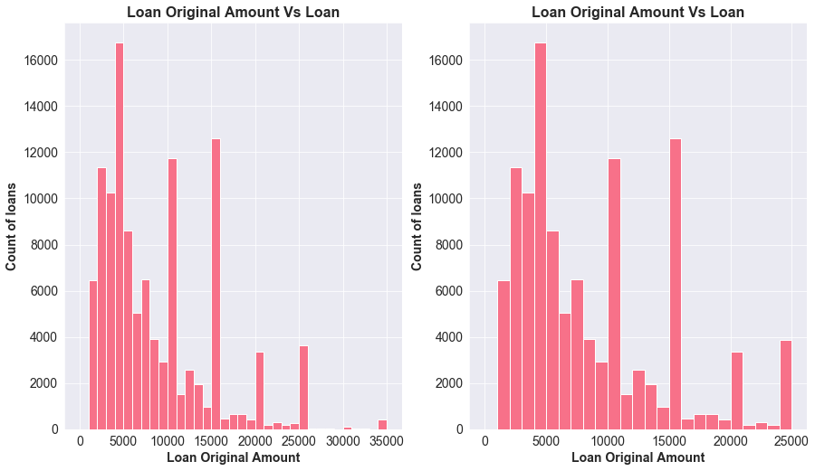

```python
plt.figure(figsize=[14.70, 8.27])
sns.set_palette("husl")


plt.subplot(1,2,1)
bin_edges = np.arange(0, num_loan['LoanOriginalAmount'].max()+1000,1000)
plt.hist(data=num_loan, x='LoanOriginalAmount', bins=bin_edges);
plt.xticks(np.arange(0, num_loan['LoanOriginalAmount'].max()+1000, 5000),fontsize=14);
plt.yticks(fontsize=14);
plt.title('Loan Original Amount Vs Loan', fontsize=16,fontweight='bold')
plt.ylabel('Count of loans', fontsize=14,fontweight='bold')
plt.xlabel('Loan Original Amount',  fontsize=14,fontweight='bold');

plt.subplot(1,2,2)
bin_edges = np.arange(0, 25000+1000,1000)
plt.hist(data=num_loan, x='LoanOriginalAmount', bins=bin_edges);
plt.xticks(np.arange(0, 25000+1000, 5000),fontsize=14);
plt.yticks(fontsize=14);
plt.title('Loan Original Amount Vs Loan', fontsize=16,fontweight='bold')
plt.ylabel('Count of loans', fontsize=14,fontweight='bold')
plt.xlabel('Loan Original Amount',  fontsize=14,fontweight='bold');
```

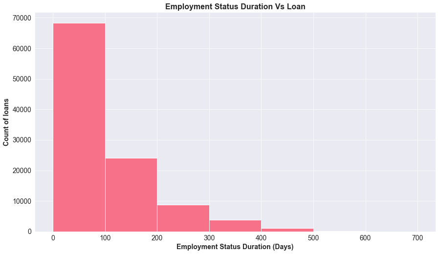

```python
plt.figure(figsize=[14.70, 8.27])
sns.set_palette("husl")

bin_edges = np.arange(0, num_loan['EmploymentStatusDuration'].max()+10, 100)
plt.hist(data=num_loan, x='EmploymentStatusDuration', bins=bin_edges);
plt.xticks(np.arange(0, num_loan['EmploymentStatusDuration'].max()+10, 100),fontsize=14);
plt.yticks(fontsize=14);
plt.title('Employment Status Duration Vs Loan', fontsize=16,fontweight='bold')
plt.ylabel('Count of loans', fontsize=14,fontweight='bold')
plt.xlabel('Employment Status Duration (Days)',  fontsize=14,fontweight='bold');
```

- Most of the borrowers have been employed for less than 3 months.

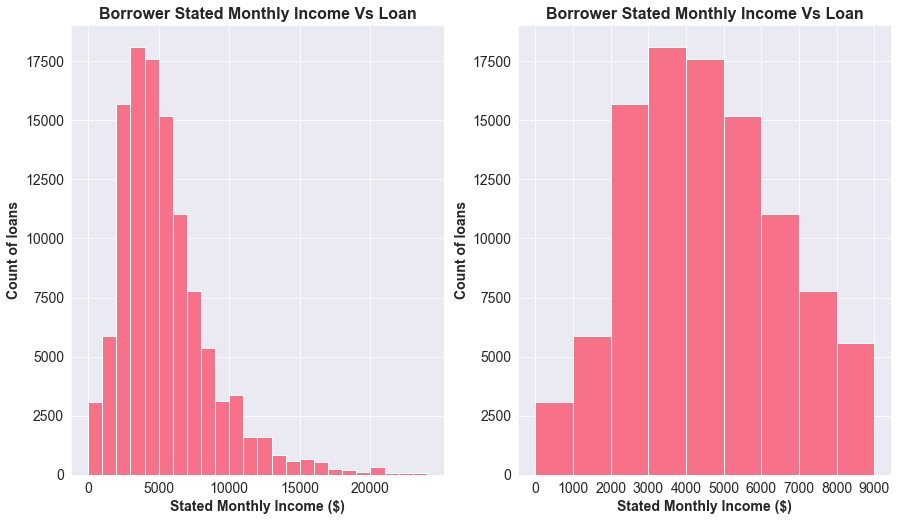

```python
plt.figure(figsize=[14.70, 8.27])
sns.set_palette("husl")
plt.subplot(1,2,1)

bin_edges = np.arange(0, 25000, 1000)
plt.hist(data=num_loan, x='StatedMonthlyIncome', bins=bin_edges);
plt.xticks(np.arange(0, 25000, 5000),fontsize=14);
plt.yticks(fontsize=14);
plt.title('Borrower Stated Monthly Income Vs Loan', fontsize=16,fontweight='bold')
plt.ylabel('Count of loans', fontsize=14,fontweight='bold')
plt.xlabel('Stated Monthly Income ($)',  fontsize=14,fontweight='bold');


plt.subplot(1,2,2)
bin_edges = np.arange(0, 10000, 1000)
plt.hist(data=num_loan, x='StatedMonthlyIncome', bins=bin_edges);
plt.xticks(np.arange(0, 10000, 1000),fontsize=14);
plt.yticks(fontsize=14);
plt.title('Borrower Stated Monthly Income Vs Loan', fontsize=16,fontweight='bold')
plt.ylabel('Count of loans', fontsize=14,fontweight='bold')
plt.xlabel('Stated Monthly Income ($)',  fontsize=14,fontweight='bold');
```

- Apart from few outliers at, most of the borrowers have stated monthly income in the range \$0 - \\$10,000 with the peak at around \$5000.

**Listing category as selected by the borrower at the time of listing, can be one of the below:**

0 - Not Available, 1 - Debt Consolidation, 2 - Home Improvement, 3 - Business, 4 - Personal Loan, 5 - Student Use, 6 - Auto, 7- Other, 8 - Baby&Adoption, 9 - Boat, 10 - Cosmetic Procedure, 11 - Engagement Ring, 12 - Green Loans, 13 - Household Expenses, 14 - Large Purchases, 15 - Medical/Dental, 16 - Motorcycle, 17 - RV, 18 - Taxes, 19 - Vacation, 20 - Wedding Loans

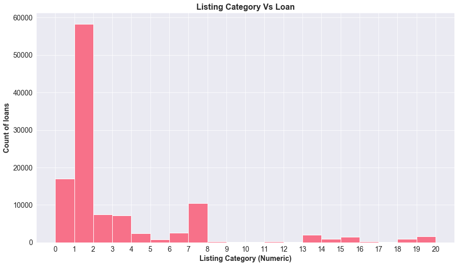

```python
plt.figure(figsize=[14.70, 8.27])
sns.set_palette("husl")

bin_edges = np.arange(0, num_loan['ListingCategoryNumeric'].max()+1, 1)
plt.hist(data=num_loan, x='ListingCategoryNumeric', bins=bin_edges);
plt.xticks(np.arange(0, num_loan['ListingCategoryNumeric'].max()+1, 1),fontsize=14);
plt.yticks(fontsize=14);
plt.title('Listing Category Vs Loan', fontsize=16,fontweight='bold')
plt.ylabel('Count of loans', fontsize=14,fontweight='bold')
plt.xlabel('Listing Category (Numeric)',  fontsize=14,fontweight='bold');
```

- Most selected category for listing is Debt consolidation i.e people are taking loans to pay off their one or many other loans.

#### Boolean Variables:

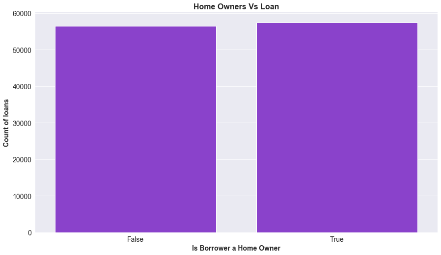

```python
plt.figure(figsize=[14.70, 8.27])
sns.set_palette("bright")

ax=sns.barplot(bool_loan.IsBorrowerHomeowner.value_counts(sort=False, dropna=False).index, bool_loan.IsBorrowerHomeowner.value_counts(sort=False,dropna=False), color=sns.color_palette()[4])
plt.title('Home Owners Vs Loan', fontsize=16,fontweight='bold')
plt.ylabel('Count of loans', fontsize=14,fontweight='bold')
plt.xlabel('Is Borrower a Home Owner',  fontsize=14,fontweight='bold')
plt.xticks(fontsize=14)
plt.yticks(fontsize=14);
```

- We have a very even distribution for borrowers being a homeowner or not. This suggests that loan distribution doesn't depend on homeownership status of the borrower.

### Bivariate Analysis:

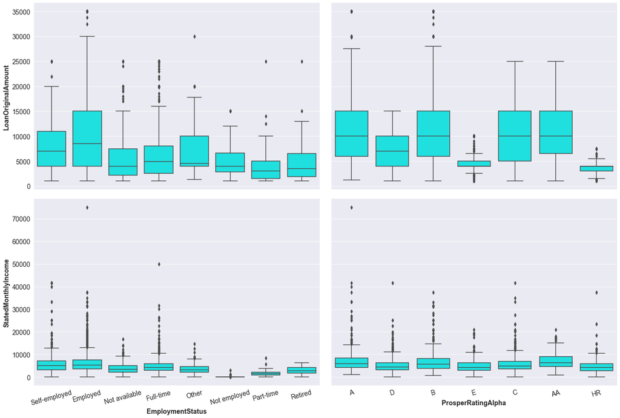

```python
# plotting a matrix of numeric variable against categorical variables with a small data sample .

def boxgrid(x, y, **kwargs):
    sns.boxplot(x, y, color = 'cyan')
    plt.xticks(fontsize=14,rotation = 15)
    plt.yticks(fontsize=14)
    plt.ylabel('x',fontsize=14,fontweight='bold')
    plt.xlabel('x',fontsize=14,fontweight='bold')


plt.figure(figsize=[14.70, 8.27])
g = sns.PairGrid(data = loan[0:5000], y_vars = [ 'LoanOriginalAmount', 'StatedMonthlyIncome'],
                x_vars = ['EmploymentStatus', 'ProsperRatingAlpha'], height = 6, aspect = 1.5)

g.map(boxgrid);
```

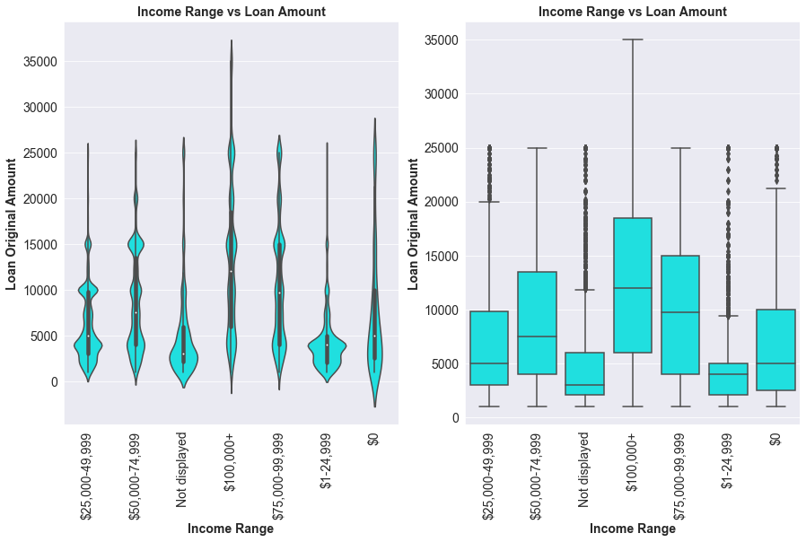

```python
plt.figure(figsize=[14.70, 8.27])

plt.subplot(1, 2, 1)
ax1 = sns.violinplot(data = loan[loan['IncomeRange'] != 'Not employed'], x = 'IncomeRange', y = 'LoanOriginalAmount', color = 'cyan')
plt.xticks(fontsize=14,rotation = 90);
plt.title('Income Range vs Loan Amount',fontsize=14,fontweight='bold')
plt.yticks(fontsize=14);
plt.xlabel('Income Range',fontsize=14,fontweight='bold')
plt.ylabel('Loan Original Amount',fontsize=14,fontweight='bold')

plt.subplot(1, 2, 2)
sns.boxplot(data = loan[loan['IncomeRange'] != 'Not employed'], x = 'IncomeRange', y = 'LoanOriginalAmount', color = 'cyan')
plt.xticks(fontsize=14,rotation = 90);
plt.title('Income Range vs Loan Amount',fontsize=14,fontweight='bold')
plt.yticks(fontsize=14);
plt.xlabel('Income Range',fontsize=14,fontweight='bold')
plt.ylabel('Loan Original Amount',fontsize=14,fontweight='bold');
```

- Loan amount and income range follow the expected trend that borrowers with higher income range are picking up loans with higher amount.

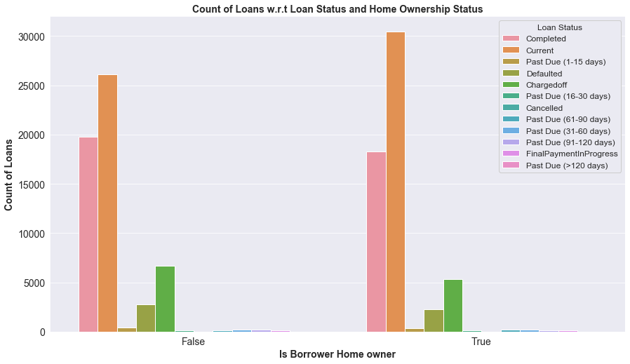

```python
plt.figure(figsize=[14.70, 8.27])

ax=sns.countplot(data = loan, hue = 'LoanStatus', x = 'IsBorrowerHomeowner');
ax.legend(loc = 1, ncol = 1, framealpha = 1, title = 'Loan Status',fontsize=12, title_fontsize=12);
plt.title('Count of Loans w.r.t Loan Status and Home Ownership Status',fontsize=14,fontweight='bold')
plt.xticks(fontsize=14)
plt.yticks(fontsize=14);
plt.xlabel('Is Borrower Home owner',fontsize=14,fontweight='bold')
plt.ylabel('Count of Loans',fontsize=14,fontweight='bold');
```

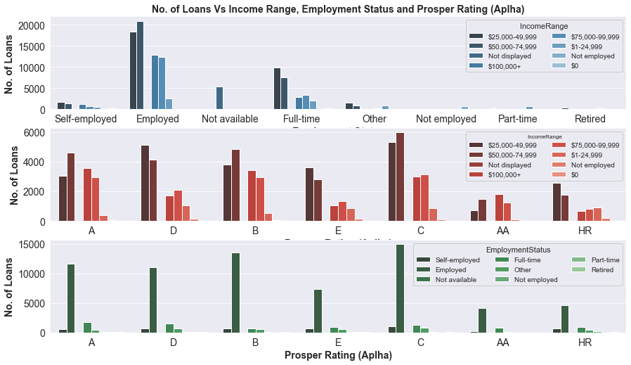

```python
plt.figure(figsize=[14.70, 8.27])

plt.subplot(3, 1, 1)
ax=sns.countplot(data = loan, x = 'EmploymentStatus', hue = 'IncomeRange', palette = 'Blues_d')
ax.legend(loc = 1, ncol = 2, framealpha = 1, title = 'IncomeRange',fontsize=10, title_fontsize=11);
plt.xticks(fontsize=14)
plt.yticks(fontsize=14)
plt.ylabel('No. of Loans', fontsize=14, fontweight='bold')
plt.xlabel('Employment Status', fontsize=14, fontweight='bold')
plt.title('No. of Loans Vs Income Range, Employment Status and Prosper Rating (Aplha)',fontsize=14, fontweight='bold')

ax = plt.subplot(3, 1, 2)
sns.countplot(data = loan, x = 'ProsperRatingAlpha', hue = 'IncomeRange', palette = 'Reds_d')
ax.legend(loc = 1, ncol = 2, framealpha = 1, title = 'IncomeRange',fontsize=10, title_fontsize=8);
plt.xticks(fontsize=14)
plt.yticks(fontsize=14)
plt.ylabel('No. of Loans', fontsize=14, fontweight='bold')
plt.xlabel('Prosper Rating (Aplha)', fontsize=14, fontweight='bold')


ax = plt.subplot(3, 1, 3)
sns.countplot(data = loan, x = 'ProsperRatingAlpha', hue = 'EmploymentStatus', palette = 'Greens_d')
ax.legend(loc = 1, ncol = 3, framealpha = 1, title = 'EmploymentStatus',fontsize=10, title_fontsize=11);
plt.xticks(fontsize=14)
plt.yticks(fontsize=14)
plt.ylabel('No. of Loans', fontsize=14, fontweight='bold')
plt.xlabel('Prosper Rating (Aplha)', fontsize=14, fontweight='bold');
```

- Most of the loans are taken by the employed borrowers who have income in the range of \$25,000 - \\$75,000
- Highest no. of loans are bagged by the borrowers who are employed and have income range in \$50,000 - \\$75,000 and have Prosper Rating as 'C'.

### Multivariate Analysis:

#### How all the variables of a loan are co-related?

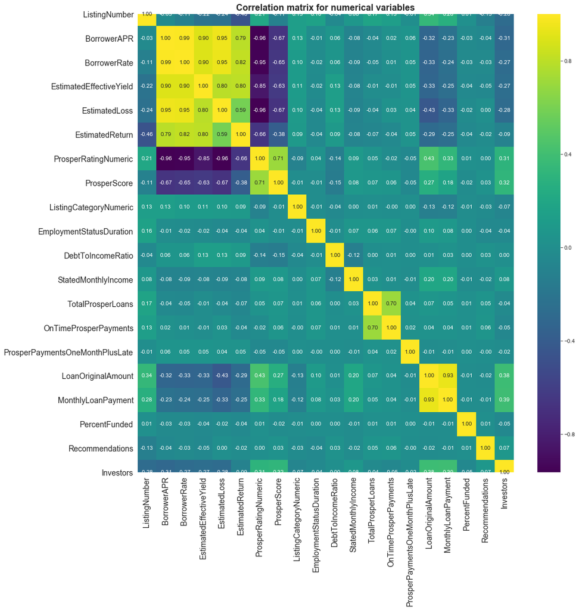

```python
plt.subplots(figsize=(15,15))

sns.heatmap(num_loan.corr(), annot = True, fmt = '.2f', cmap = 'viridis');
plt.title('Correlation matrix for numerical variables', fontsize=16,fontweight='bold')
plt.xticks(fontsize=14)
plt.yticks(fontsize=14);
```

- Loan original amount and monthly loan payment is highly correlated and it is expected and borrowers interest rate and proper score are highly correlated(-vely), Borrower interest rate and loanamount are -vely correlated.

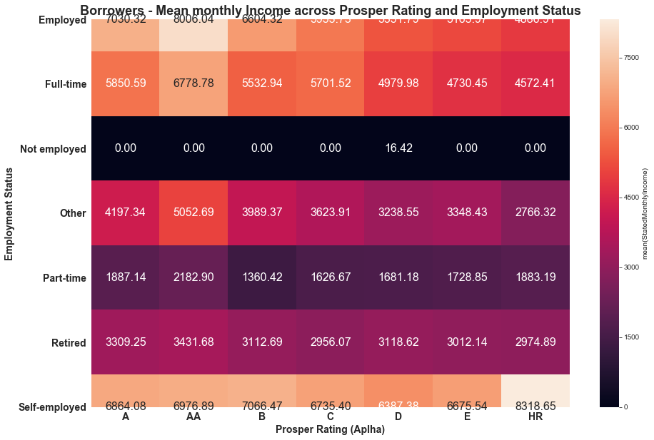

```python
plt.figure(figsize = [15, 10])


cat_means = loan.groupby(['ProsperRatingAlpha', 'EmploymentStatus']).mean()['StatedMonthlyIncome']
cat_means = cat_means.reset_index(name = 'StatedMonthlyIncome_avg')
cat_means = cat_means.pivot(index = 'EmploymentStatus', columns = 'ProsperRatingAlpha',
                            values = 'StatedMonthlyIncome_avg')
sns.heatmap(cat_means, annot = True,annot_kws={"fontsize":16}, fmt = '.2f',
           cbar_kws = {'label' : 'mean(StatedMonthlyIncome)'});
plt.title('Borrowers - Mean monthly Income across Prosper Rating and Employment Status', fontsize=18, fontweight='bold')
plt.xticks(fontsize=14, fontweight='bold')
plt.yticks(fontsize=14, rotation =0, fontweight='bold')
plt.ylabel('Employment Status', fontsize=14, fontweight='bold')
plt.xlabel('Prosper Rating (Aplha)', fontsize=14, fontweight='bold');
```

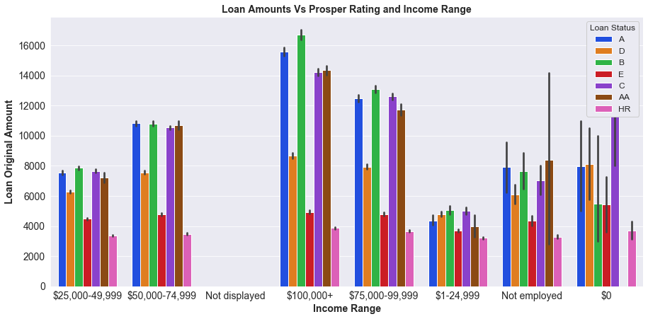

```python
plt.figure(figsize = [15, 7])

ax=sns.barplot(data = loan, hue = 'ProsperRatingAlpha', x = 'IncomeRange', y = 'LoanOriginalAmount');
ax.legend(loc = 1, ncol = 1, framealpha = 1, title = 'Loan Status',fontsize=12, title_fontsize=12);
plt.title('Loan Amounts Vs Prosper Rating and Income Range',fontsize=14,fontweight='bold')
plt.xticks(fontsize=14)
plt.yticks(fontsize=14);
plt.xlabel('Income Range',fontsize=14,fontweight='bold')
plt.ylabel('Loan Original Amount',fontsize=14,fontweight='bold');
```

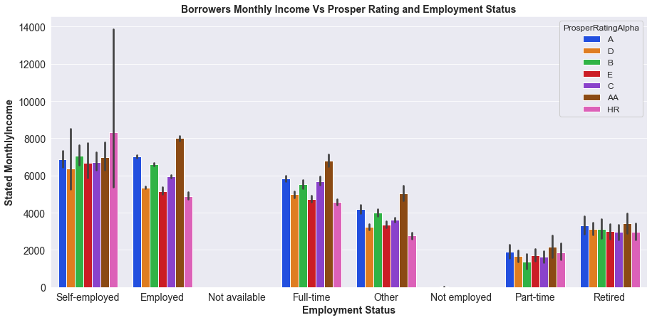

```python
plt.figure(figsize = [15, 7])
ax = sns.barplot(data = loan, x = 'EmploymentStatus', y = 'StatedMonthlyIncome', hue = 'ProsperRatingAlpha')
plt.title('Borrowers Monthly Income Vs Prosper Rating and Employment Status',fontsize=14,fontweight='bold')
ax.legend(loc = 1, ncol = 1, framealpha = 1, title = 'ProsperRatingAlpha',fontsize=12, title_fontsize=12);
plt.xticks(fontsize=14)
plt.yticks(fontsize=14);
plt.xlabel('Employment Status',fontsize=14,fontweight='bold')
plt.ylabel('Stated MonthlyIncome',fontsize=14,fontweight='bold');
```